# 프로젝트 : 얼굴을 인식하여 캐릭터 씌우기

## Face Detection vs Face Recognition

패키지 설치

> pip install mediapipe

```python
import mediapipe as mp
```

눈, 코, 입에 점 찍기

```python
import cv2
import mediapipe as mp

# 얼굴을 찾고, 찾은 얼굴에 표시를 해주기 위한 변수 정의
mp_face_detection = mp.solutions.face_detection # 얼굴 검출을 위한 face_detection 모듈을 사용
mp_drawing = mp.solutions.drawing_utils # 얼굴의 특징을 그리기 위한 drawing_utils 모듈을 사용

# 동영상 파일 열기
cap = cv2.VideoCapture('face_video.mp4')
# with문 : 파일 자동으로 close 해줌
with mp_face_detection.FaceDetection(model_selection=0, min_detection_confidence=0.7) as face_detection:
    while cap.isOpened(): # 동영상이 잘 열렸는지 확인해서 while문 실행
        success, image = cap.read() # frame 하나씩 불러와서 image에 저장. 성공하면 넘어감
        if not success: # 동영상을 불러올 경우는 'continue' 대신 'break'를 사용
            print("동영상을 불러 올 수 없습니다.")
            break

        # To improve performance, optionally mark the image as not writeable to
        # pass by reference.
        # 필요에 따라 성능 향상을 위해 이미지 작성을 불가능함으로 기본 설정
        image.flags.writeable = False
        image = cv2.cvtColor(image, cv2.COLOR_BGR2RGB) # image를 cvtColor를 통해 BGR을 RGB로 바꿈(mediapipe는 BGR보다 RBG 기준으로 처리)
        results = face_detection.process(image) # process : image로부터 얼굴을 검출(face_detection)해 결과(results)로 반환


        # Draw the face detection annotations on the image. # 포즈 주석을 이미지 위에 그림
        image.flags.writeable = True # False를 True로 바꿔줌(예제에 있어서 그냥 씀)
        image = cv2.cvtColor(image, cv2.COLOR_RGB2BGR) # RGB -> BGR

        if results.detections: # 검출된 얼굴이 있으면
            for detection in results.detections: # 검출된 사람 얼굴만큼 드로우 해줌
                mp_drawing.draw_detection(image, detection) # 위에서 얼굴을 검출한 값 results를 이용해서 얼굴을 그림(네모도 그리고 점도 찍음)
                #print(detection)

        # Flip the image horizontally for a selfie-view display.
        cv2.imshow('MediaPipe Face Detection', cv2.resize(image, None, fx=0.5, fy=0.5)) #작업된 image를 resize를 통해 0.5배로 축소

        # cv2.flip(image, 1) : 보기 편하게 이미지를 좌우 반전

        if cv2.waitKey(1) == ord('q'):
            break

cap.release()
cv2.destroyAllWindows()
```

#### model_selsection

-> 모델 0 or 1  
-> 선택 0 : 카메라로부터 2m 이내의 근거리(가까운 거리에서 촬영된 얼굴이 적합)  
-> 선택 1 : 카메라로부터 5m 이내의 장거리(먼 거리에서 촬영된 얼굴이 적합)

#### min_detection_confidence

-> 어느정도 %(신뢰도)로 인식하면 얼굴로 검출하는지 정의 (threshold(임계값) 개념)(0~1 사이의 값을 넣음)

#### print(detection)를 통해 detection 정보를 출력하면

score : 신뢰도(min_detection_confidence)  
location_data : 위치  
format : bounding_box로 네모 정보를 줌

xmin, ymin, width, height : x좌표, y좌표, 너비, 높이 (전체 이미지 기준으로 가로, 세로를 1로 봄)  
relative_keypoints : 6개의 keypoints 정보를 알려줌  
keypoints : 얼굴에서 사람 특징을 좌표로 뽑아내는 것 -> 오른쪽 눈, 왼쪽 눈, 코 끝부분, 입 중심, 오른쪽 귀, 왼쪽 귀( 귀구슬점 or 이주)

> 한 프레임마다 이 detection 정보가 반복됨

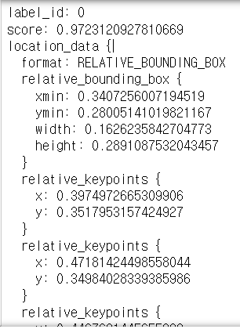

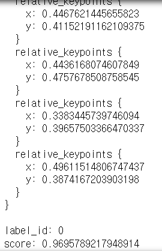

[figure not shown]

양 눈과 코에 동그라미 그리기

```python
import cv2
import mediapipe as mp

# 얼굴을 찾고, 찾은 얼굴에 표시를 해주기 위한 변수 정의
mp_face_detection = mp.solutions.face_detection # 얼굴 검출을 위한 face_detection 모듈을 사용
mp_drawing = mp.solutions.drawing_utils # 얼굴의 특징을 그리기 위한 drawing_utils 모듈을 사용

# 동영상 파일 열기
cap = cv2.VideoCapture('face_video.mp4')
# with문 : 파일 자동으로 close 해줌
with mp_face_detection.FaceDetection(model_selection=0, min_detection_confidence=0.7) as face_detection:
    while cap.isOpened(): # 동영상이 잘 열렸는지 확인해서 while문 실행
        success, image = cap.read() # frame 하나씩 불러와서 image에 저장. 성공하면 넘어감
        if not success: # 동영상을 불러올 경우는 'continue' 대신 'break'를 사용
            print("동영상을 불러 올 수 없습니다.")
            break

        # To improve performance, optionally mark the image as not writeable to
        # pass by reference.
        # 필요에 따라 성능 향상을 위해 이미지 작성을 불가능함으로 기본 설정
        image.flags.writeable = False
        image = cv2.cvtColor(image, cv2.COLOR_BGR2RGB) # image를 cvtColor를 통해 BGR을 RGB로 바꿈(mediapipe는 BGR보다 RBG 기준으로 처리)
        results = face_detection.process(image) # process : image로부터 얼굴을 검출(face_detection)해 결과(results)로 반환


        # Draw the face detection annotations on the image. # 포즈 주석을 이미지 위에 그림
        image.flags.writeable = True # False를 True로 바꿔줌(예제에 있어서 그냥 씀)
        image = cv2.cvtColor(image, cv2.COLOR_RGB2BGR) # RGB -> BGR

        if results.detections: # 검출된 얼굴이 있으면
            for detection in results.detections: # 검출된 사람 얼굴만큼 드로우 해줌
                # mp_drawing.draw_detection(image, detection) # 위에서 얼굴을 검출한 값 results를 이용해서 얼굴을 그림(네모도 그리고 점도 찍음)
                #print(detection)

                # 특정 위치 가져오기
                keypoints = detection.location_data.relative_keypoints
                right_eye = keypoints[0] # 오른쪽 눈
                left_eye = keypoints[1] # 왼쪽 눈
                nose_tip = keypoints[2] # 코 끝부분

                h, w, _ = image.shape # height, width, channel(안씀) : 이미지로부터 세로, 가로, 크기 가져옴
                right_eye = int(right_eye.x*w),int(right_eye.y*h) # 이미지 내에서 실제 좌표 (x, y)를 정수형 형태로 right_eye에 저장
                left_eye = int(left_eye.x*w), int(left_eye.y*h)
                nose_tip = int(nose_tip.x*w), int(nose_tip.y*h)

                # 양 눈에 동그라미 그리기
                cv2.circle(image, right_eye, 50, (255,0,0), 10, cv2.LINE_AA) # 파란색
                cv2.circle(image, left_eye, 50, (0,255,0), 10, cv2.LINE_AA) # 초록색

                # 코에 동그라미 그리기
                cv2.circle(image, nose_tip, 50, (0,255,255), 10, cv2.LINE_AA) # 노란색

        # Flip the image horizontally for a selfie-view display.
        cv2.imshow('MediaPipe Face Detection', cv2.resize(image, None, fx=0.5, fy=0.5)) #작업된 image를 resize를 통해 0.5배로 축소

        # cv2.flip(image, 1) : 보기 편하게 이미지를 좌우 반전

        if cv2.waitKey(1) == ord('q'):
            break

cap.release()
cv2.destroyAllWindows()
```

[figure not shown]

그림판 이미지 씌우기

```python
import cv2
import mediapipe as mp

# 얼굴을 찾고, 찾은 얼굴에 표시를 해주기 위한 변수 정의
mp_face_detection = mp.solutions.face_detection # 얼굴 검출을 위한 face_detection 모듈을 사용
mp_drawing = mp.solutions.drawing_utils # 얼굴의 특징을 그리기 위한 drawing_utils 모듈을 사용

# 동영상 파일 열기
cap = cv2.VideoCapture('face_video.mp4')

#그림판 이미지 불러오기
image_right_eye = cv2.imread('right_eye.png') # 100 x 100
image_left_eye = cv2.imread('left_eye.png') # 100 x 100
image_nose = cv2.imread('nose.png') # 300 x 100 (크기- 가로 x 세로)

# with문 : 파일 자동으로 close 해줌
with mp_face_detection.FaceDetection(model_selection=0, min_detection_confidence=0.7) as face_detection:
    while cap.isOpened(): # 동영상이 잘 열렸는지 확인해서 while문 실행
        success, image = cap.read() # frame 하나씩 불러와서 image에 저장. 성공하면 넘어감
        if not success: # 동영상을 불러올 경우는 'continue' 대신 'break'를 사용
            print("동영상을 불러 올 수 없습니다.")
            break

        # To improve performance, optionally mark the image as not writeable to
        # pass by reference.
        # 필요에 따라 성능 향상을 위해 이미지 작성을 불가능함으로 기본 설정
        image.flags.writeable = False
        image = cv2.cvtColor(image, cv2.COLOR_BGR2RGB) # image를 cvtColor를 통해 BGR을 RGB로 바꿈(mediapipe는 BGR보다 RBG 기준으로 처리)
        results = face_detection.process(image) # process : image로부터 얼굴을 검출(face_detection)해 결과(results)로 반환


        # Draw the face detection annotations on the image. # 포즈 주석을 이미지 위에 그림
        image.flags.writeable = True # False를 True로 바꿔줌(예제에 있어서 그냥 씀)
        image = cv2.cvtColor(image, cv2.COLOR_RGB2BGR) # RGB -> BGR

        if results.detections: # 검출된 얼굴이 있으면
            for detection in results.detections: # 검출된 사람 얼굴만큼 드로우 해줌
                # mp_drawing.draw_detection(image, detection) # 위에서 얼굴을 검출한 값 results를 이용해서 얼굴을 그림(네모도 그리고 점도 찍음)
                #print(detection)

                # 특정 위치 가져오기
                keypoints = detection.location_data.relative_keypoints
                right_eye = keypoints[0] # 오른쪽 눈
                left_eye = keypoints[1] # 왼쪽 눈
                nose_tip = keypoints[2] # 코 끝부분

                h, w, _ = image.shape # height, width, channel(안씀) : 이미지로부터 세로, 가로, 크기 가져옴
                right_eye = int(right_eye.x*w) - 20,int(right_eye.y*h - 100) # 이미지 내에서 실제 좌표 (x, y)를 정수형 형태로 right_eye에 저장
                left_eye = int(left_eye.x*w) + 20, int(left_eye.y*h - 100)
                nose_tip = int(nose_tip.x*w), int(nose_tip.y*h)

                # 각 특징에 이미지 그리기 (우리가 덮어 씌울려는 이미지 크기만큼 해당하는 영역으로 대체)
                image[right_eye[1]-50:right_eye[1]+50, right_eye[0]-50:right_eye[0]+50] = image_right_eye # right_eye 그림판 이미지를 오른쪽 눈 y좌표 기준으로 위로 50, 아래로 50 / x좌표 기준으로 왼쪽으로 50, 오른쪽으로 50 바꿈
                image[left_eye[1]-50:left_eye[1]+50, left_eye[0]-50:left_eye[0]+50] = image_left_eye
                image[nose_tip[1]-50:nose_tip[1]+50, nose_tip[0]-150:nose_tip[0]+150] = image_nose # 코 가로 크기가 300이라 그걸 반으로 나눈 150을 사용

        # Flip the image horizontally for a selfie-view display.
        cv2.imshow('MediaPipe Face Detection', cv2.resize(image, None, fx=0.5, fy=0.5)) #작업된 image를 resize를 통해 0.5배로 축소

        # cv2.flip(image, 1) : 보기 편하게 이미지를 좌우 반전

        if cv2.waitKey(1) == ord('q'):
            break

cap.release()
cv2.destroyAllWindows()
```

그림판 이미지 하얀 배경 제거해서 캐릭터 이미지 씌우기

```python
image_right_eye = cv2.imread('right_eye.png')
image_right_eye.shape
```

```
(100, 100, 3)
```

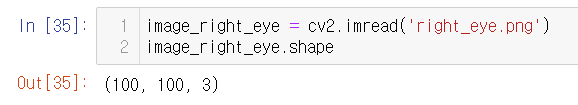

mage.shape : height, width, channel

> 투명도를 가지는 이미지 : 4 채널 이미지

-> 이미지를 불러올 때 아무 옵션을 제공하지 않으면 투명도를 제외한 컬러 영역만 불러옴  
-> 투명도를 불러오기 위해 cv2.IMREAD_UNCHANGED 사용

```python
import cv2
import mediapipe as mp

def overlay(image, x, y, w, h, overlay_image) : # 대상 이미지 (3채널), x,y 좌표, width, height, 덮어씌울 이미지 (4채널)
    alpha = overlay_image[:,:,3] #BGRA에서 A(투명)값만 alpha로 가져옴 (list는 0부터 시작)
    mask_image = alpha / 255 # 원래 값 0~ 255 -> 255로 나누면 0 ~ 1 사이의 값 (1 : 불투명, 0 : 완전 투명)
    # (255, 255) -> (1, 1)
    # (255, x) -> (1, 0.3)

    # 1 - mask_image
    # -> (0, 0)
    # -> (0, 0.7)
    # 반전

    for c in range (0, 3) : # channel BGR 순서대로
        image[y-h:y+h, x-w:x+w, c] = (overlay_image [:, :, c] * mask_image) + (image[y-h:y+h, x-w:x+w, c] * (1 - mask_image))



    # 얼굴을 찾고, 찾은 얼굴에 표시를 해주기 위한 변수 정의
mp_face_detection = mp.solutions.face_detection # 얼굴 검출을 위한 face_detection 모듈을 사용
mp_drawing = mp.solutions.drawing_utils # 얼굴의 특징을 그리기 위한 drawing_utils 모듈을 사용

# 동영상 파일 열기
cap = cv2.VideoCapture('face_video.mp4')

#그림판 이미지 불러오기
image_right_eye = cv2.imread('right_eye.png', cv2.IMREAD_UNCHANGED) # 100 x 100   # cv2.IMREAD_UNCHANGED 를 추가해 3채널(컬러)에서 4채널(+투명도)로 변경
image_left_eye = cv2.imread('left_eye.png', cv2.IMREAD_UNCHANGED) # 100 x 100
image_nose = cv2.imread('nose.png', cv2.IMREAD_UNCHANGED) # 300 x 100 (크기- 가로 x 세로)

# with문 : 파일 자동으로 close 해줌
with mp_face_detection.FaceDetection(model_selection=0, min_detection_confidence=0.7) as face_detection:
    while cap.isOpened(): # 동영상이 잘 열렸는지 확인해서 while문 실행
        success, image = cap.read() # frame 하나씩 불러와서 image에 저장. 성공하면 넘어감
        if not success: # 동영상을 불러올 경우는 'continue' 대신 'break'를 사용
            print("동영상을 불러 올 수 없습니다.")
            break

        # To improve performance, optionally mark the image as not writeable to
        # pass by reference.
        # 필요에 따라 성능 향상을 위해 이미지 작성을 불가능함으로 기본 설정
        image.flags.writeable = False
        image = cv2.cvtColor(image, cv2.COLOR_BGR2RGB) # image를 cvtColor를 통해 BGR을 RGB로 바꿈(mediapipe는 BGR보다 RBG 기준으로 처리)
        results = face_detection.process(image) # process : image로부터 얼굴을 검출(face_detection)해 결과(results)로 반환


        # Draw the face detection annotations on the image. # 포즈 주석을 이미지 위에 그림
        image.flags.writeable = True # False를 True로 바꿔줌(예제에 있어서 그냥 씀)
        image = cv2.cvtColor(image, cv2.COLOR_RGB2BGR) # RGB -> BGR

        if results.detections: # 검출된 얼굴이 있으면
            for detection in results.detections: # 검출된 사람 얼굴만큼 드로우 해줌
                # mp_drawing.draw_detection(image, detection) # 위에서 얼굴을 검출한 값 results를 이용해서 얼굴을 그림(네모도 그리고 점도 찍음)
                #print(detection)

                # 특정 위치 가져오기
                keypoints = detection.location_data.relative_keypoints
                right_eye = keypoints[0] # 오른쪽 눈
                left_eye = keypoints[1] # 왼쪽 눈
                nose_tip = keypoints[2] # 코 끝부분

                h, w, _ = image.shape # height, width, channel(안씀) : 이미지로부터 세로, 가로, 크기 가져옴
                right_eye = int(right_eye.x*w) - 70,int(right_eye.y*h - 100) # 이미지 내에서 실제 좌표 (x, y)를 정수형 형태로 right_eye에 저장
                left_eye = int(left_eye.x*w) + 70, int(left_eye.y*h - 100)
                nose_tip = int(nose_tip.x*w), int(nose_tip.y*h)

                # image, x, y, w, h, overlay_image
                overlay(image, *right_eye, 50, 50, image_right_eye)
                overlay(image, *left_eye, 50, 50, image_left_eye)
                overlay(image, *nose_tip, 150, 50, image_nose)

        # Flip the image horizontally for a selfie-view display.
        cv2.imshow('MediaPipe Face Detection', cv2.resize(image, None, fx=0.5, fy=0.5)) #작업된 image를 resize를 통해 0.5배로 축소

        # cv2.flip(image, 1) : 보기 편하게 이미지를 좌우 반전

        if cv2.waitKey(1) == ord('q'):
            break

cap.release()
cv2.destroyAllWindows()
```

[figure not shown]

## def문 보충설명

```python
def overlay(image, x, y, w, h, overlay_image) : # 대상 이미지 (3채널), x,y 좌표, width, height, 덮어씌울 이미지 (4채널)
    alpha = overlay_image[:,:,3] #BGRA에서 A(투명)값만 alpha로 가져옴 (list는 0부터 시작)
    mask_image = alpha / 255 # 원래 값 0~ 255 -> 255로 나누면 0 ~ 1 사이의 값 (1 : 불투명, 0 : 완전 투명)
    # (255, 255) -> (1, 1)
    # (255, x) -> (1, 0.3)

    # 1 - mask_image
    # -> (0, 0)
    # -> (0, 0.7)
    # 반전

    for c in range (0, 3) : # channel BGR 순서대로
        image[y-h:y+h, x-w:x+w, c] = (overlay_image [:, :, c] * mask_image) + (image[y-h:y+h, x-w:x+w, c] * (1 - mask_image))
```

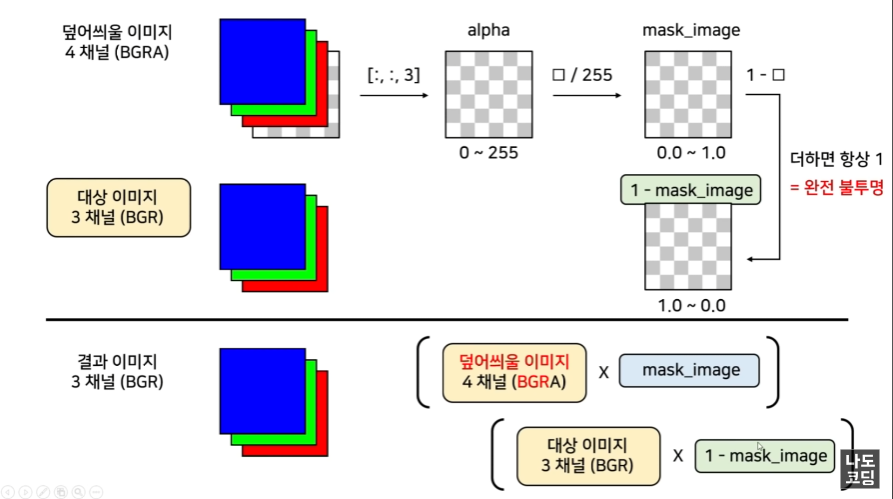

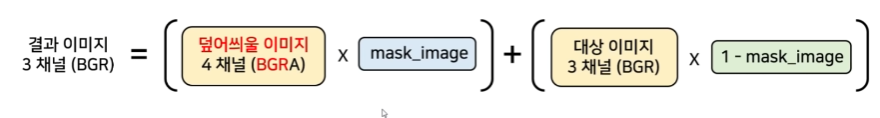

이와 같음  
image[y-h:y+h, x-w:x+w, c] = (overlay_image [:, :, c] *mask_image) + (image[y-h:y+h, x-w:x+w, c]* (1 - mask_image))

#### 예시 1)

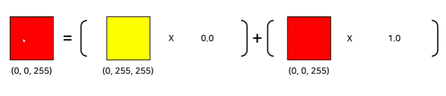

> 덮어씌울 이미지 중에서 mask_image가 1이면 완전 불투명, 0이면 완전 투명

노란색은 완전 투명  
빨간색은 완전 불투명

=> 노란색+빨간색 = 빨간색 이미지 그대로

#### 예시 2)

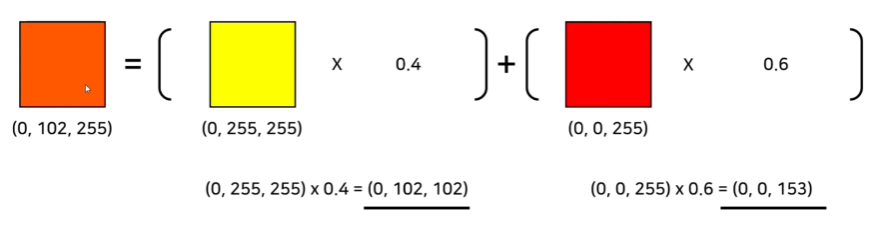

노란색 : (0x0.4, 255x0.4, 255x0.4) = (0, 102, 102)  
빨간색 : (0x0.6, 0x0.6, 255x0.6) = (0, 0, 153)

=> 노락색 + 빨간색 = (0+0, 102+0, 102+153) = (0, 102, 255)